# Notes from “An introduction to Linguistics”

Hicham Mellouki

# Table of contents

### I : What is Language?

### II : Lexis

### III : Semantics

### IV : Phonetics

### V : Phonology

# I : What is Language?

## 1.1 The Significance of Language

> “For better or worse, the human race dominates life on Earth.” - *Stuart C. Poole*
1. Chimpanzees can be trained to respond in accordance with different **symbolic gestures**, but they lack a **larynx** and a **mouth** that allow the articulation of a wide ranger of distinguishable sounds. Without these they are doomed to making little progress (*In their building a power station endeavor*). The same goes for us, without an extremely complex system of communication like that provided by our speech, the odds to succeed are low/inferior. Also, it is difficult to refer to anything that is removed from us in space and time, anything that we cannot *point to here and now*.
2. Far simpler tasks require language: *language for learning*, *language for planning*, *language for co-operation*.
3. language is more efficient to learn and adapt to changing circumstances far more quickly than *evolution*[^1]; **A word of warning** from a father to his son is an adequate way to adapt him into the environment than is a process of **natural selection**[^2] whereby those not inclined to do the right thing are eventually *weeded out*.
4. Even though, **honey bees** have a remarkable way of letting others know where nectar lies through their “waggle-dance”[^3], but they can not discuss the merits of other foodstuffs or alternative ways of building their homes.
5. According to Christians’ beliefs, God felt obliged to restrict language, due to the massive power it yields mankind; in Genesis, chapter 11, we read that the plans to build a tower, that of Babel, up to Heaven were countered by God putting an end to the common language:

> “And the Lord said, Behold, the people is one, and they have all one language; and this they begin to do: and now nothing will be restrained from them, which they have imagined to do.”

## 1.2 What is Language

1. Before we embark on our study of language, we should have an idea of what the term *“language”* means. As a first response, it might be that language relates to communication between human beings and not to communication between animals.
2. One attempt to define human language was made by the American linguist **Charles F. Hockett**. He enumerated a number of features, which he argued, constitute human language. Other communication systems might exhibit one or more of these features but only human language has them all.
   - **Interchangeability** : *any creature that can transmit the information can also recieve such information and vice versa*. (e.g. the “dance” of honey bees)
   - **Productivity** : *The ability to vary a message to reflect differences in the circumstances concerned*; this is clearly necessary in a case where the source of the nectar may be constantly changing.
   - **Cultural Transmission** : It is acquired from others. (Honey-bees does not meet this criterion)
3. An earlier American linguist, **Edward Sapir** supported the hypothesis that language relates to communication between human beings. Just as Hockett was to associate human language with cultural transmission, so too Sapir considered that it is **‘non-instinctive’** and **‘voluntarily produced’**. His definition is as follows:

> “Language is purely human and non-instinctive method of communicating ideas, emotions, and desires by means of a system of volunatrily produced symbols.” - *Edward Sapir*
1. He considers these **symbols** in the first place as *auditory*; Thus language is primarily a *matter of speech* as opposed to say, *sign language*.
2. Symbols vs. System
   - The element **‘symbols’** reflects the fact that there is rarely an inherent association between a *word* and *the object* or concept that it denotes; Hence, the words *perro*, *chien* and *hond* refer all to “dog”.
   - The element **‘system’** reflects the fact that language provides us with the framework for generating appropriate utterances rather than providing us with an infinite store of ready-made utterances – We can create utterances never uttered before (Discrete infinity).
3. According to the British linguist, **David Crystal**, language is a human vocal noise (or the graphic representation of this noise in writing) that is used systematically and *conventionally* by a community for purposes of communication; Thus this definition also proposes **communication** as the principal function of language.
4. Any particular language is culturally transmitted – a children acquires the language of the society in which it grows up, irrespective of the language of its parents –. It is now generally accepted that humans inherit a predisposition towards acquiring language.
5. The modern linguist and cognitive scientist **Steven Pinker** uses the word **instinct** to embody the essence of human language.
6. Instinctive vs. Non-instinctive
   - Language is **instinctive** as we are all born with a predisposition to speak, we all acquire a language without tuition and when we speak we do not *consciously* convert our thoughts into speech.
   - Language is non-instinctive in that we can choose what to say or whether to say anything at all.
7. **R. H. Robins** distills a simplistic definition which might help us to focus our study of language :

> “Language is a form of human communication by means of a system of symbols principally transmitted by vocal sounds.” – *R. H. Robins*

## 1.3 The Functions of Language

1. The functions of language could be covered with the term *communication*, but it is more than that.
2. So far, the author has mentioned three functions:
   - **Phatic communion** : The use of speech with the aim of establishing or maintaining social relations. In this situation, saying nothing might be taken as a sign of displeasure.
   - **Emotive utterance** : An expression of emotion such as *That’s fantastic!* or *Shit!*
   - **Performative utterance** : When an utterance is being spoken by somebody with relevant authority. It is an act by itself. (e.g. *I declare this bridge open* or *I promise…*) =/ **Constative** (e.g. *It is raining*)

## 1.4 What is a Language?

- language, the faculty, for communication by speech sounds, is a universal characteristic of the human race. It is a medium of communication specific to a society; it forms part of the culture of that society. Also, it is inherited genetically, whereas we acquire “a Language” which we get exposed to in our early childhood.

## 1.5 The Elements of Language

*This section is full of examples and definitions concerning the subdisciplines we are expected to study.*

1. **Lexis** : The study of words.
2. **Semantics** : The study of (rules for) meaning, of the relationship between word and the real world.
3. **Phonetics** : The study of speech sounds, and how sounds are produced/perceived.
4. **Phonology** : The study of rules of speech sounds (pronunciation).
5. **Morphology** : The structure of words – the study of rules for forming words.
6. **Syntax** : The study of rules for forming phrases/sentences.
7. **Historical linguistics** : The study of how languages change and evolve.
8. **Regional variation** : Language variations based primarily on geographic distribution and their associated features.
9. **Social variation** : Variations in language due to the different social characteristics of the speakers (e.g. class/gender/race etc…).

## Summary

Speech has allowed human beings to develop in a completely different way from other animals. This is due in large part to the cultural transmission that our speech allows, which facilitates a faster adaptation to changes in our environment.

Language is generally considered to be a form of communication between human beings by means of a system of symbols which are principally transmitted by vocal sounds. While the faculty of speech is considered to be inherited, the system that we use, the specific language, is determined by the society in which we grow up, it being culturally transmitted.

Communicating by speech requires symbols to be transmitted orally in order that shows the relationship between them. The form of utterance will be affected by geography and social factors.

Our utterances have a variety of functions in addition to communicating facts; we may speak to express our emotions, for example, or to reinforce a relationship with somebody.

# II : Lexis

## 2.1 What Is a Word?

A unit of meaning can range from an **idiom**, a phrase that has a meaning not apparent from its constituent worsd, to a **morpheme**, a minimal unit of meaning of which there may be several in a word.

**Lexeme** or **lexical item** to denote an item of vocabulary with a single referent whether it consists of one word or more than one word. The term *lexeme* also allows greater precision in that the forms *gives, gave*, and so on, can be considered to be different forms of the one lexeme: *give*. The lexeme, which one can equate to the form that one would look up in a dictionary, encompasses the set of inflectional forms that may be used to realise the lexeme in various environments. (go, going, goes)

##### So how can we define a word?

Useful tests might be indivisibility, insertion and substitutability. Words are indivisible and they can be inserted between other words; we can insert *large* between *the* and *dog* but not within *dog*. We can substitute the word *cat* for the word *dog*. But then much the same can be said of phrasal lexemes like *kick the bucket* and *give in*. Similarly, morphemes cannot be divided, can be inserted and can be substituted; the *un-* of *uninformed* can, for example, be replaced by *mis-*.

> “A word, then, is a free form which does not consist entirely of (two or more) lesser free forms; in brief, a word is a *minimum free form*.” – **Leonard Bloomfield**

In the end, however, we may have to accept that – setting aside the convention of leaving spaces between sequences of characters in the written language – it is difficult to define satisfactorily what a word is. The range of meaning or function encompassed by a word varies from language to language. The French equivalent of *I shall give* is represented by two words: *je donnerai*, the marker for the future tense being incorporated in the verb (-rai). In Spanish only one word is required, *daré*, the element -*é* being considered sufficient to indicate who is going to do the giving.

## 2.2 Where Do Words Come From?

The association between word and object is a matter of **convention**.

So if words have no inherent relationship with objects in the real word, what determins their form?

Firstly, of course, some words do have something of an inherent relationship with the thing that they denote. This is clearly the case with :

1. **Onomatopoeic** words : words which represent sounds or things which make a sound. (i.e. bang, crash, meow(nya)…)
2. Other words, though not directly imitative, may also exhibit **sound symbolism**, may also reflect the nature of the object or concept that they denote. (larger: *geek* or gock?) It has been argued, for example, that **high front vowels**, those produced with the tongue raised towards the front of the mouth, tend to be indicative of smallness and express **diminutives**; cf. Scots *wee*, Swedish *liten*, French and Catalan *petit*, the diminutive suffixes of Italian (-*ino), Spanish (-*ito*) and Portoguese (-*inho*). **Clusters** : sl- (smoothly wet), kr- (noisy impact as in* crash*), -omp (clumsiness as in* clump* and *thump*), bl- (may imitate inflation as in *blow*, *blast*, *bladder*)…
3. **Conversion** : altering the word class. (table (Noun) –> to table (Verb))
4. **Derivation** : adding morphemes to form new words. (cover, dis-cover, un-dis-covered, dis-cover-er…)
5. **Backformation** : a word that is formed from an already existing word from which it appears to be a derivative, often by removal of a suffix (e.g., *laze* from *lazy* and *edit* from *editor*)
6. Alternatively, a new word may result from **compounding** of existing elements in the language. In this way we acquired numerous words like *houseboat* and *boathouse*.
7. The elements of a compound may be merged such that at least one element is abbreviated. In this way, for example, the phrase *motor cavalcade* became *motorcade*, *camera recorder* became *camcorder*. Such forms are **blend** words.
8. A language can form new compounds using elements taken from the classical languages. The word *television* is composed from Greek element indicating a distance and a Latin element indicating sight. In the field of medicine, terminology is generally based on classical elements; *hepatitis*, for example, is based on the Greek equivalent of *liver*. Such words are called **neo-classical compounds**.
9. A language can also, of course, acquire a word ready-made from another language. An object or concept acquired from another society may be given the label used by that society. Thus the word *sauna* came to us from Finnish, and the word *croissant* from French. When a word is adopted by one language from another it is referred to as a **loanword**. Loanwords may retain a pronunciation similat to that which they had in their language of origin or the pronunciation may be adapted to the phonology of the adoptive language. Some people retain the French pronunciation of the word *garage* with the sound /ʒ/ but others place this rather alien sound with /dʒ/.
10. **Calque** : A calque is a lexeme adopted in translated form by one language from another, as the English lexeme *honeymoon* was adopted by French as *lune de miel*. Also called **loan translition**.
11. A word may derive from the name of a place or person. The word *copper* derives from *Cyprus*. Items may be named after the person who invented or discovered them; thus the Italian Alessandro Volta gave his name to the volt and the Italian Luigi Galvani gave his name to the process of galvanization.
12. **Popular etymology** : the popular modifying of the form of a word to make it seem to be derived from familiar words, as *crayfish* for *crevisse*.

## Summary

We commonly consider the word to be a fundamental building block of language, but as units of meaning may be expressed by more than one word, linguistics has the concept of lexeme.

Some lexemes are arguably have some intrinsic association with the things that they denote, but the origins of most words are lost in the mists of time. What we can establish is how these elements subsequently provide the lexemes that we use. New lexemes can be produced from native elements by such means as derivation, semantic extension and compounding or from foreign elements by such means as borrowing or translating foreign words.

# III : Semantics

## 3.1 The Function of Lexemes

**Content word** : a word which denotes something in real world. (e.g. daughter, terrorist)

**Function word** : a word expressing a formal or grammatical purpose. (e.g. *of* to indicate relationship, *the* for specifying)

One can draw a parallel with an algerbraic expression like 3y + 2z; the and the can be likened to content words in that they are symbols that represent something substantial, while the symbol <+> can be likened to a function word - it represents the function of addition in much the same way as the function word *and* indicates summation. The use of content words changes as society changes but the use of function words is much more stable.

In this chapter our attention will be focused on content words. Function words belong rather to the field of syntax.

## 3.2 The Meaning of Meaning

1. Clearly words often specify something in the real world. To use the terms employed by the Swiss linguist **Fredinand de Saussure**, the word *daughter* is a *signifiant*, the thing that signifies, and the category of relative concerned is a *signifié*, the thing that is signified.
2. In their work entitled *The Meaning of Meaning* **C. K. Ogden** and **I. A. Richards** maintained that the word, what they called the **symbol**, and the actual object, the **referent**, are linked only indirectly, by way of our mental perception of that object, the **thought** or **reference**. More recently, **Stephen Ulmann** suggested that we might use more common terms: **name** to denote the sequence of sounds that is the physical form of the utterance, **thing** to denote the object or event that is being referred to, and **sense** to denote the information that the name conveys to the hearer.
3. Other linguists have been loathe to accept an intermediate conceptual stage in the process of communication. Ogden and Richards went on to question the role of mental images:

> “There are good reasons why attempts to build a theory of interpretation upon images must be hazardous. One of these is the grave doubt whether in some minds they ever occur or ever have occured.”

## 3.3 Semantic Range

1. In order to be able to deal with the world around us we have to put *labels* on things. This has required us to divide the world up into *categories* and to force an infinitely varied world into these categories. We have a category labelled *dog* into which we put *poodles* and *spaniels* but not foxes and wolves.
2. The more significant an object or concept is to a community, the greater the tendencey to lexicalise the label used to denote it, to have a more succinct term. (e.g. Arabs: horses, camels. Eskimo: types of snow)
3. The division that we draw in order to define our categories are very haphazard. In English we use the same verb, *play*, to denote the very different activies of a child amusing himself with his toys and a pianist performing at a concert. When we eat lambs we call the meat *lamb* but when we eat calves we use a different word for the meat: *veal*. We distinguish between roofs and ceilings but Spaniards do not; they use *techo* /tis/ for both.
4. The arbitrariness is clearly likely to be all the greater where there is little natural distinctiveness in the subject area concerned. It is fairly clear cut what is and what is not an egg. But how big does a hill have to be before it is a mountain? How big does a village have to be before it is a town? The more arbitrary the division, the less reason there is for different languages to make divisions at the same points; thus for example, the Spanish word *pueblo* equates to a large village or a small town. What we call a *river* can be denoted by either *fleuve* or *rivière* in French, the general view being that the former flows into the sea while the latter flows into another river.
5. The set of items that we identify by means of a word or lexeme is the **semantic range** of that word or lexeme. Such sets may be grouped with others with which they share a common feature to form a **semantic field**. Thus the semantic range of the English word *red* is that part of the colour spectrum that we denote with this word, a range considerably more restricted than that of the corresponding term in a language that distinguishes only three colours. The range of *red* together with that of the other colour terms can be referred to as **the semantic field of colour**.

## 3.4 The Definition of Semantic Range

> “It isn’t the colour red that takes the place of the word red, but the gesture that points to a red object.” – Wittgenstein, *The Big Typescript*

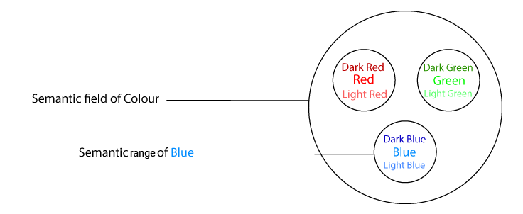

1. **Hyponymy** : The relationship in which more specific terms are arranged under their more general superodinate terms. (e.g. The word *poodle* is a hyponym of *dog* which in turn is a hyponym of the word *mammal*. | The wolf & dog belong to the genus *Canis*, the dog being the *Canis familiaris* and the wolf the *Canis lupus*.). *The hyponyms of a word define its semantic range*. A superordinate like *mammal* or *animal* can serve to designate a semantic field.
2. **Componential analysis** : is the semantic analysis of a lexeme in terms of the presence or absence of distinctive features. Words denoting family relationship lend themselves to such a binary approach; words like *daughter*, *son* and *mother* denote either a male person or a female person, either an earlier generation or a later generation, and so on.

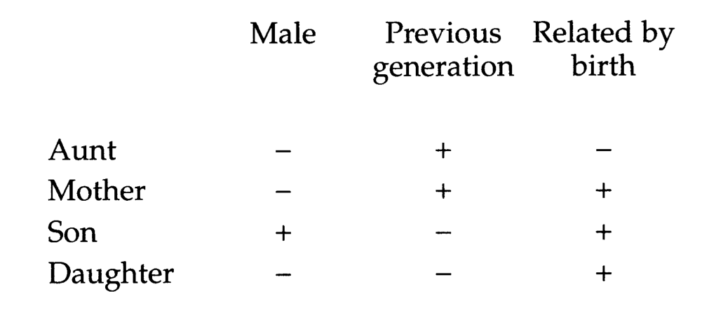

3. The semantic range of a word can be defined with the assistance of another word that means the same thing, a **synonym**, or a word that means the opposite, an **antonym**. Thus it can help us to use the word *large* if we know that it means much the same as the word *big* or that it means the opposite of the word *small*.
4. Synonyms & Antonyms
   - Hide vs. Conceal
     - Hide from Old English. Conceal from Old French.
     - Conceal cannot serve as an intransitive verb. while hide can, so they are not complete synonyms as they cannot substitute each other in all circumstances. In this case the difference was one of *syntax*. In the case of the words *high* and *tall* there is a difference of *reference*; both may be used to qualify buildings but only *tall* can be used to refer to the *height (!) of people.
     - In the case of antonyms we have to consider different types of relationship. The words *tall* and *short* are opposites, antonyms, as are the words *alive* and *dead*. There is, however, a fundamental difference between these two pairs, for while one person can be shorter than another, one person cannot be more dead than another; thus *tall* and *short* are termed **gradable antonyms** and *alive* and *dead* are termed **complementary antonyms**.
     - When looking at antonyms we should note that a word can have different antonyms in different contexts (syntagmatic). cf. short person /= tall person, short walk but not tall walk
5. Some linguists have concluded that *one knows a word by the company that it keeps* (J. R. Firth) or that *the meaning of a word is its use in the language* (Ludwig Wittgenstein).

## 3.5 Collocation and Idiom

1. **Collocation** : When a word becomes closely associated with a particular context to the exclusion of other words with a similar meaning such that they form what is almost a set phrase, we have what linguists call **collocation**. From a logical point of view we could perhaps refer to a *complete moon* but we don’t, we refer to a full moon*. White coffee is not white and black coffee is not black; it would seem that* white* and *black* are being used to indicate polarity rather than to give an accurate indication of colour. If something is not far away a Catalan might refer to the distance as four steps (*quatre passes*); an Italian would tell you that it is only two steps (*due passi*) away. We can refer to a flock of sheep but not a flock of cows. Sometimes, the associate is so close that we can anticipate it; most of us would, for example, except *She has blond*… to be followed by *hair*. *Geoffrey Leech* refers to collocation as simply an in idiosyncratic property of individual words.
2. **Idiom** : When the phrase can only be understood as an entity. (e.g. White lie = “purity of intention”). The independence of the meaning of their constituent words gives idioms great freedom. (e.g. *smutty joke*, *one man’s meat is another man’s poison*)

## 3.6 Homonymy and Polysemy

1. **Polysyemy** : One lexeme with a variety of referents. (e.g. sound, lamb)
2. **Homonyms** : Each of two or more words having the same spelling or pronunciation but different meanings (e.g. pole). Unlike polyesemic items, lexicographers will treat homonyms as different items, giving each one the status of a separate *headword*.
3. **Homophones** : Each of two or more words having the same pronunciation but different meanings. (e.g. meet/meat, see/sea, new/knew)
4. **Homographs** : Each of two or more words spelled the same but not necessarily pronounced the same and having different meanings. (e.g. wind –> /waynd/ or /wInd/)

Etymology is not always a good guide; the word *bank* denoting a financial institution and that denoting the shore of a river, two items that are semantically very distinct, are etymologically related.

## 3.7 The Human Element of Meaning

1. **Connotation** : The first thing that comes to your mind when you hear a word. (e.g. *turkey* (Britons = Xmas, Americans = Thanksgiving))
2. Attitudes : The same person may well be called a terrorist by an oppoent and a freedom fighter by a sympathizer.
3. **Taboo** vs. **Euphemism**
   - **Taboo** : a word that we are loathe to use. (cock)
   - **Euphemism** : A word that it more acceptable substitute. (roaster)
4. **Geoffrey Leech’s seven aspects of meaning** :
   - **Conceptual** (denotative) : defines the meaning of a lexeme in terms of its constituent features. Thus, to use the componential analysis, the conceptual meaning of the lexeme *woman* can be defined in terms of such properties as +human, -male and +adult.
   - **Connotative** meaning : What comes first when hearing a lexeme differs from an individual to another.
   - **Stylistic** : A lexeme may be more appropriate in a particular style. (e.g. *cast* == literary style vs. *chuck* == colloquial)
   - **Affective** : Our response to one sense of a lexeme may be affected by another sense of that lexeme. (e.g. *Shut up*)
   - **Reflected** : Arises when a word has more than one conceptual meaning or multiple conceptual meaning. (the word **gay** was frequently used in the time of William Wordsworth for merry, but the word now is used for **homosexuality**.
   - **Collocative** : Lexemes used with certain other lexemes but not with others. (e.g *blond hair*)
   - **Thematic** : The emphasis that attaches to a lexeme as the result of the speaker’s choice of grammatical structure or his use of stress. (e.g. *John broke the vase*)

## 3.8 Pragmatics

We communicate more than we say explicitly. This disparity between what we intend to communicate and what we actually say is central to pragmatics. It is bridged by what the speaker implies and what the listener infers on the basis of shared knowledge, shared assumptions and the context of the utterance.

**Grice’s maxims** to facilitate communication by being co-operative:

1. **Quality** : The tendency for an utterance to be true.
2. **Quantity** : The tendency for the amount of information given to be appropriate.
3. **Relevance** : The relevancy to the current situation.
4. **Manner** : Information is usually presented in an orderly fashion.

**Context** is a major source of supplementary information.

**Proximity** (Common ground, Shared knowledge & intention) between speaker and listener minimises what has to be explicitly said.

The extent of the knowledge shared by speaker and listener determines the amount of explicit information required.

**Deixis** : The situation in which the referent of a lexeme is dependant on the context. e.g. personal pronouns, demonstrative adverbs, definite article, adjectives and pronouns. A deictic item being an item which has very little referential force without the support of context. (e.g. possessive adjectives like her and her dog are considered to be deictic (idiosyncratic)).

The categorisation of utterances by function, by **speech act** :

1. Statements (**Declarative utterances**) : SVO. (e.g. *He shuts the door.*)
2. Questions (**Interrogative utterances**) : VSO (e.g. *Can you shut the door?*)
3. Requests or commands (**Imperative or directive utterances**) : VO (e.g. command –> *Shut the door.*)
4. **Performative utterance** : Relating to or denoting an utterance by means of which the speaker performs a particular act. (e.g. *I apologize*, *I bet*, *I promise* | *hereby*..). An utterance is, however, only a performative utterance if the conditions necessary to make it an act prevail (**felicity conditions**). I apologize only constitutes an apology is the speaker has done something wrong and acknowledges that he has done so.
5. **Felicity condition** : A felicity condition is a condition that must apply before an utterance can constitute a speech act; *I promise to do it tomorrow* is no promise if the speaker is unable to do what is promised or if he does not feel bound by his utterance.

## 3.9 Discourse Analysis

Closely allied to pragmatics, perhaps part of it, is **discourse analysis** or **conversation analysis**, this being the study of the organisation and the dynamics of conversation.

We are more at ease when a conversation flows smoothly. We are less at ease if there are pauses in the conversation or if, conversely, two people are speaking at the same time (overlap). We dislike people interrupting, beginning to speak at an inappropriate point. Discourse analysis *investigates the mechanisms that facilitate smooth flow in coversations*.

One topic of study, for example, has been turn-taking, how the “floor” passes from one person to another with a minimum of disruption. One techniques for handing over the floor is using Tag questions (isn’t it), another one is the use of a falling intonation contour.

Reflecting Grice’s co-operative principle, we are happier going along with a proposition.

## Summary

Words may be divided into **content words**, those which identify something in the world around us, and **function words**, those which serve to specify, link, and so on the content words. The set of objects, action, and so on that such a word denotes is known as the **semantic range** of that word.

The semantic range of a word can be defined by such techniques as **hyponomy** and **componential analysis**, by reference to **synonyms** and **antonyms**. **Context** contributes to defining the range of a word. In some contexts the meaning of a word cannot be fully determined without reference to a wider phrase; in such a phrase where there is a conventional association between the consitutent words we are dealing with **collocation** or, if the constituent words give little, if any, indication of the meaning of the phrase, **idiom**.

It is not always clear whether two words represent two different meanings of the one lexeme or are two different lexemes; in the case of the former we are dealing with **polysemy**, in the case of the latter with **homonymy**.

We communicate more than we say explicitly. This can be so because we are generally **co-operative**, generally want to help the listener to understand. What we need to say is minimised by the *support provided by the context in which the utterances takes place* and by *shared knowledge*. Such factors full within the study of pragmatics. Related to pragmatics is discourse analysis, the study of the organisation and dynamics of conversations.

# IV : Phonetics

## 4.1 The Organs of Speech

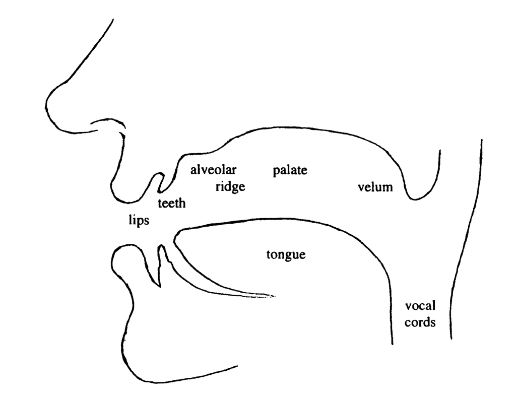

We can communicate certain things by clapping our hands, by clicking our fingers, by frowning, and so on. But by far the greatest part of the transmission of utterances from one person to another is done by means of speech sounds. The study of these speech sounds is **phonetics**. Speech sounds may be referred to as phonetic **segments** or **phones**.

The power source of our speech sounds is the flow of air from our lungs. The distinctiveness of each sound results from the way in which the flow of air is manipulated as it passes through the throat and head.

The vocal cords are located in the larynx, in what we perceive as the “Adam’s apple”. When certain consonant sounds are produced, the vocal cords are open and the flow of air passes unimpeded, such sounds are **voiceless**. When other consonants and vowels are produced, the vocal cords are closed with the result that they vibrate as the flow of air forces its way between them; such sounds are **voiced**. The sound [f], for example, is voiceless. The voiced equivalent is [v].

## 4.2 Consonants

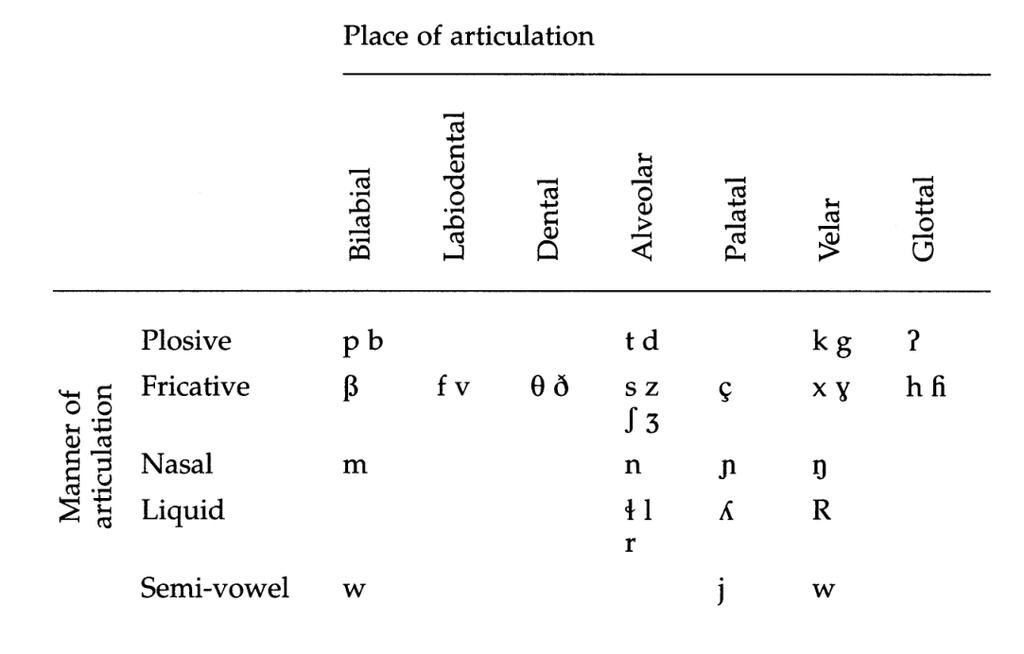

Consonants are determined by whether the vocal cords vibrate, where the air is impeded and how it is impeded; to use the linguist’s terminology, they are termined by **voicing**, by **place of articulation** and by **manner of articulation**. (e.g. The sound [p] is a voiceless bilabial plosive).

**Sibilants** : [ʃ], [ʒ], [s] and [z].

## 4.3 Phonemic Notation

George Bernard Shaw highlighted the lack of precision in English orthography by spelling the word *fish* as *ghoti*.

The palato-alveolar sounds that British linguists generally represent by [ʃ], [tʃ], [ʒ] and [dʒ] are, for example, represented in the United States by [s], [c], [z] and [j].

The phonemic alphabet can be made more precise by supplmeneting the character with a diacritic; the aspirated [t] can be represented by [th]. More precise transcription like this is called **narrow transcription**.

- Narrow transcription vs. Broad transcription
  - **Narrow transcription** : It is the precise phonetic transcription, in which each unit is a phone. This type of transcription is used inside square brackets. e.g. [bæd]
  - **Broad transcription** : It is the phonological transcription, in which each unit is a phoneme. This type of transcription is used inside slashes. e.g. /bæd/

## 4.4 Vowels

The core of a syllable is usually a **vowel**. It is the nature of vowels that they are *voiced*. What differentiaties them is the way the **tongue** and the **lips** shape the channel through which the air passes after leaving the larynx. When we say *least* our tongue is raised at the front and our lips are **spread**. When we say *loosed* our tongue is raised at the back and our lips are **rounded**.

Vowels produced when the tongue is high are called **close** vowels and vowels produced when the tongue is low are called **open** vowels. Vowels produced when the tongue is pushed forward are called **front** vowels and vowels produced when the tongue is drawn back are called **back** vowels. It is the vowels particularly that give rise to regional and social variations in accent.

There is a tendency for front vowels to be accompanied by lips that are *spread* rather than rounded and for back vowels to be accompanied by lips that are *rounded* rather than spread.

Because of the variability of vowels, linguists find it useful to have a set of reference points to which they can relate the vowels of a language. Such a set of reference points, proposed by the British phonetician Daniel Jones, is known as the **cardinal vowels**. There are eight primary cardinal vowels. Vowels are usually represented by a point on a trapezium that is a stylised representation of the vowel space in the mouth, the front of the mouth being understood to be the left.

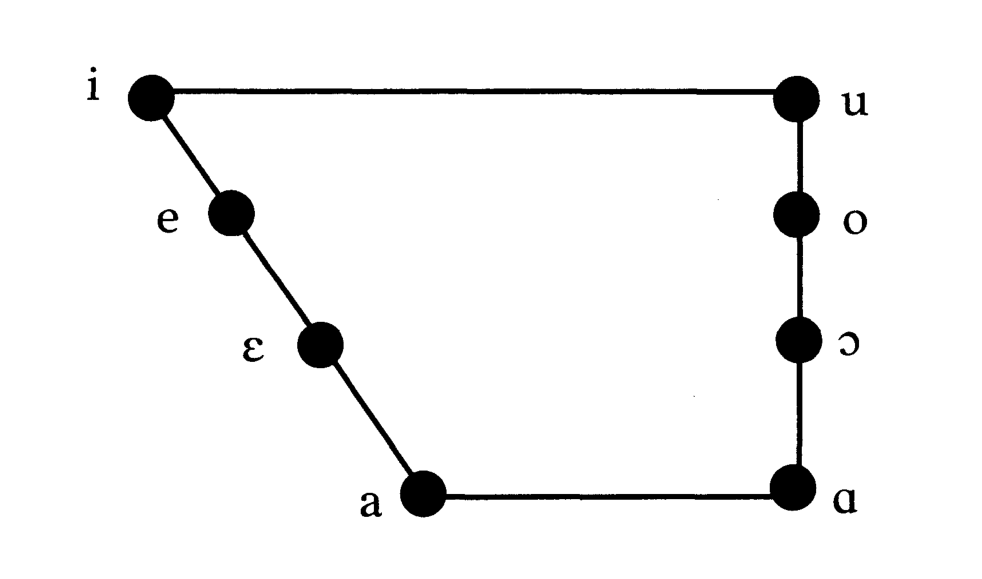

Gliding vowels sounds are **diphthongs** (/ei/, /au/, /ai/…). The exact nature of a diphthong is a matter of debate among linguists. Some consider it to be a single segment, regarding it to be a sequence of two segments. This latter position allows further debate: are the two segments always vowels or may be one a semi-vowel? Some words may even have **triphthong**, such as the /auə/ of *hour*.

## 4.5 Sounds in Sequence

### **Assmilation**

Thus there is a tendency for sounds to adopt a feature of neighbouring sounds, a process known as **assimilation**.

In the word *unkind* the prefix *un-* is pronounced /ŋ/, the nasal sound being velar in anticipation of the velar /k/. In the word *unblievable*, it is pronounced /m/ to share with the /b/ilabial articulation. These are examples of **assimilation of the place of articulation**. Such assimilation may have been reflected in the spelling of a word; if we put somebody into prison we *incarcerate* or *imprison* them.

1. **Progressive assimilation** : assimilation to a preceding segment as with the plural morpheme. (voiced con. + /z/ and voiceless con. + /s/)
2. **Regressive assimilation** : assimilation to a following segment, as with the negating morpheme in */əŋkaind/*.

## Summary

Consonant sounds are defined in terms of where they are articulated, how they are articulated and whether or not the vocal cords are engaged. Vowels are defined in terms of the position of the tongue and the shape of the lips. A diphthong is a glide from one vowel position to another within a syllable. The distinction between consonant and vowel is not absolute; consonants vary in the degree to which the air flow is constricted, in their degree of sonority, and some can stand in a syllable without a vowel.

Sound segments are not articulated in isolation from each other and one may influence a neighbouring segment to minimise the movement of the articulators in the course of speech.

The International Phonetic Alphabet allows a more precise representation of sounds than conventional alphabets do. Phonetic transcription may be broad or narrow.

## V : Phonology

## 5.1 Sound System of Languages

#### Phonetics vs. Phonology

1. **Phonetics** : is concerned with the production of sounds which can serve as speech sounds in a language.
2. **Phonology** : studies sounds in the context of languages and other speech varieties. It is concerned with which sounds a language uses and how it arranges them. It is concerned with the contribution of sounds to the task of communication. We might describe phonology as applied phonetics.

## 5.2 The Phoneme

A pair of words that are distinguished by just one segment is called a **minimal pair**. (e.g. pan, ban, fan)

When the occurence of one sound as opposed to another is determined by their phonetic environment the sounds concerned are said to be in *complemntary distribution*.

## 5.3 Phonological Rules

We know that *stape* could be an English word and that *zdape* could not. A phonologist needs to know why we would accept one and not the other, why one is in accord with the phonological system of English and the other is not. He needs to know why even if we have never seen a word before, we would agree that the plural morpheme of *toves* is realised as /z/ and why that *stapes* is realised as /s/.

We could say that the plural morpheme is /s/ after such consonants as f, k, p, and /z/ after such consonants as b, d, g, l, m, n. But it is more efficient and leads to greater understanding if one identifies the underlying forces. The force in this case is the common one of assimilation, and the phonologist will very quickly observe that voiceless consonants are accompanied by the voiceless /s/ and that voiced consonants are accompanied by the voiced /z/. So effieciency and understanding result from identifying the operative **distinctive features**., in this case *voicing*.

Where more than one rule affects a word, one has to consider the rule ordering, for the final form that the word takes may depend on the order in the rules affected it. (e.g *an* in French)

## 5.4 The Phonology of English

/p/ as in pan /f/ as in fan /ʃ/ as in shatter /m/ as in man

/t/ as in tan /θ/ as in thank /tʃ/ as in chatter /ŋ/ as in thing

/d/ as in done /ð/ as in than /dʒ/ as in junk /l/ as in lung

/k/ as in can /s/ as in sank /w/ as in won /r/ as in rung

/g/ as in gun /z/ as in zinc /j/ as in young /h/ as in hung

There are restrictions on how we use our phonemes and the phonologist has to understand what these restrictions are in order to identify the phonological rules affecting the phonetic environments in which phonemes can and cannot occur (**phonotactics**). It may be that a phoneme cannot occur in a certain position: *in English /ŋ/ cannot occur in initial position*. There will be restriction on which other phonemes a phoneme may accompany; */kn/ is not possible in initial position* because *initial clusters of consonants must either begin with /s/ or end with a liquid or a semi-vowel*. Thus the words *snot* and *clot* can be pronounced /snɔt/ and /klɔt/ but the wod *knot* cannot be pronounced /knɔt/. *An English syllable can have up to three consonant segments before the vowel (CCCV). (e.g. /str/ as in* strong*, /skw/ as in* square*, and* up to four after the vowel (VCCCC). e.g. /ksts/ as in *texts*.

Some vowels are longer than other; the vowel of the word *least*, for example, is longer than that of *list*. Some linguists use this feature to distinguish between the close vowels, showing length by means of a color; thus *least* would be transcribed as /li:st/ and *list* as /list/. But these two sounds are articulated somewhat differently, the former being more close and more front than the latter, and some linguists choose to use different symbols, /i/ for the vowel in *least* and /I/ for that in *list*. Using these symbols, the twelve simple vowels of Standard British English are as follows:

```
/i:/ as in least    /ə:/ as in learn        /u:/ as in Luke

/i/ as in list      /ə/ as in the (unstressed)  /u/ as in look

/e/ as in less      /ʌ/ as in luck          /ɔ:/ as in lord

/æ/ as in lass      /ɑ:/ as in last         /ɔ/ as in lost
```

The vowel represented by /ə/, known as schwa, is widespread in English, unstressed vowels being commonly realised as this vowel. The first vowel of the word *ballon*, for example, is represented by /ə/ as opposed to /ɔ:/ of *ball*. The words *phonetics* and *fanatics* are only distinguished by the stressed second syllable, the first syllable having the vowel /ə/ in both cases. The two vowels of the word *hazard* are /æ/ and /ə/.

The eight diphthongs are as follows:

```
/iə/ as in tear (in the eye)    /uə/ as in tour

/ei/ as in tray         /ou/ as in throw

/ɛə/ as in tear         /ɔi/ as in toy

                /ai/ as in tie

                /au/ as in town
```

We have been looking at the sounds of Standard British English, the variant of English that is said to be spoken with **received pronunciation** (RP).

Americans generally voice /t/ after a stressed vowel and before an unstressed vowel with the result that one might be left wondering whether somebody spent the morning writing or riding. Many Americans would pronounce the vowel in *lost* with a lower tongue position, producing /ɑ:/ rather than /ɔ/. For Standard British English /au/ shows a rearward glide in the case of the London ‘Cockneys’ and a forward glide in the case of the people of Northern Ireland. If a person from Northern Ireland told you that he found the child’s mouse one might be excused for thinking that he is using the present tense and that he finds more than one mouse.

## 5.5 The Phonology of Other Languages

Different languages have different phonological rules and it may require some effort for a speaker of one language to adapt to the phonological rules of another language. Just as Spaniards seek the aid of a vowel to articulate /st/, we have inserted a vowel between the /k/ and the /n/ to produce *Canute*. Not having the glottal fricative [h], Spaniards often use the velar equivalent [x], their *jota*, when speaking English.

Having for the most part lost the segment /ʃ/, Spaniards might be well advised to avoid the passages of Jordan. (intended joke from the Bible!)

The word *shibboleth* has come into English from Hebrew to refer to a test word or speech peculiarity.

Different languages, then, use different phonemes. French and German have fewer phonemes than English; some thirty-five. While the French and the Germans both have initial /ʃ/ they might be in trouble by the end of the word *shibboleth* as they do not have the dental fricatives /θ/ and /ð/; hence the popular perception that Frenchmen and Germans pronounce *the* as /z/. French does not have a phoneme that corresponds to our velar nasal /ŋ/. One the other it has a palatal nasal // that we do not have, this being the final segment of *Bretagne*. Nor do we have the velar or uvular liquid /R/ that French has, the sound that is so striking (impressive) when one hears a recording of Edith Piaf signing *Non, je ne regrette rien. (e.g. /Rod/ in Sweden for* red*)

Comparison at the level of narrow transcription reveals many more differences. The English word *time* begins with an aspirated alveolar plosive, /th/, wheareas the Spanish word *tiempo* begins with a dental plosive, /t/. The English word *think* begins with a /θ/ *articulated with the tongue against the upper teeth*, while the Spanish word *cinci* begins with a /θ/ *articulated with the tongue between the teeth*.

Different languages compound consonants in different combinations. English accepts the initial cluster /sk/ as in *school* but not the voiced equivalent /zg/.

There is a natural tendency towards open syllables consisting of a consonant and a vowel, a syllable structure of CV. This is the usual structure in Japanese. Thus when Japanese adopts foreign words with clusters, vowels are inserted; in this way the equivalent of *milk* is, when transcribed into Roman script, *miruku*, and *girlfriend* has become *garufurendo*.

**Vowel harmony** is the approximation of the vowel in a suffix to that in a root, typically such that both are front or back vowels. This is a feature of, for example, Finnish and Turkish (the plural affix is *-lar* when the preceding vowel is a back vowel, and *-ler* when it is a front vowel.

## 5.6 Suprasegmental Features

We now have a good acquaintance with the speech sounds, the segments, of language. We need to rise above the segment, to consider **suprasegmental features**.

A major unit greater than the segment is the **syllable**. The concept of the syllable is supported by many phonological rules. As an example, monosyllabic words in English tend to be of the same length, a *vowel being longer when followed by a voiced consonant than when followed by a voiceless consonant*, the voiced consonants being shorter than the voiceless consonants, and longer still when no consonant follows; thus in the words *seat, seed* and *see* the vowels are progressively longer.

Every syllable has a **nucleus**, its power source. This is usually a vowel but it can also be a liquid or nasal consonant as in the second syllable of the word *people*: /pi:pl/. A *syllable may consist of nothing but the nucleus, as in the word* owe*, but the nucleus is usually accompanied by at least one consonant. A preceding consonant, or consonant cluster is called an **onset** and a following consonant or consonant cluster is called **coda**. The nucleus and the coda may be viewed as a unit, the **rhyme**.

The quality of vowels is affected by **stres**, by increases in pressure of air expelled by the lungs and increases in the tension of the vocal cords. In English, *invalid* and *entrance* have different meanings depending on whether one stresses the first or the second syllable. There are many pairs in English where stress distinguishes between verb and noun, an example being /kən’trɑst/ and /’kɔntrɑst/. Talking of contrast, stress is also function in that it can indicate emphasis or contrast, as in *I wanted the white one, not the green one*.

As we have just seen when we say *I wanted the white one* we put greater stress on the word *white* if we want to emphasise that we did not want one of another colour. This alters the pitch variation of the utterance, produces a different **intonation** contour, a different ‘melody’.

# VI : Morphology

## 6.1 The Composition of Words

The word *black* is a *minimal unit* in so far as it cannot be broken down into smaller semnatic or functional units.

A word must contain an element that can stand by itself, such as *black*; such an element is called a **root**. It may contain more than one root, in which case it is a compound word (for example *blackbird*). It may contain one or more elements that cannot stand by themselves, such as the *-en* and the *-ed* in *blackened*; such elements that can only exist when joined to a ‘host’ are called **affixes** and the ‘host’ maybe called a **base**. Affixes may be joined to the begging of the base, in which case they are called **prefixes**, or to the end of the base, in which case they are called **suffixes**. There are other alternatives such as infixes that are significant in some languages.

#### Language typology :

1. **Agglutinating** languages : being a language in which such concepts (in *talossani*) as are realised as preposition and possessive adjectives in English are realised as affixes.??
2. **Isolating** or **Analytic** languages : each concept being expressed by a separate word.
3. **Inflecting** languages : such languages, like French, make greater use of affixes than analytic languages do.

## 6.2 Morphemes

A **morpheme** is a minimal functional element of a word.

As we have seen, some elements can stand by themselves and some cannot. The former we call roots, the latter we call affixes. They can also be referred to as **free morphemes** and **bound morphemes** respectively.

## 6.3 Derivation and Inflection

In section 6.1, we drew a distinction between the elements *-en* and *-ed* in the word *blackened*. The element *-en* created a new lexeme, a label for the action of making something black, while the element *-ed* restricted functionally the lexeme *blacken*. The first case is an example of **derivation**, the second example is of **inflection**.

Derivation, being concerned with the creation of new labels, draws morphology towards lexis while inflection, being concerned with function, draws morphology towards syntax.

Derived words are syntactically unmarked, whereas inflected words are marked in some way; inflected nouns may be marked for the plural, inflected verbs may be marked for person or tense. A derivational affix may produce a related lexeme of a different word class (as with the verb *wish* and the verb *wished*). Derivational suffixes are less predictable in occurence; while *weak* acquired the noun form *weakness*, *strong* acquired the noun form *strength*. Derivational affixes are also less predictable semantically; while *fatherhood* denotes the state of being a father, *brotherhood* denotes an association of men as well as the state of being a brother. Inflectional affixes are more productive, that is they can be used with new words, this being facilitated by their greater predictability; as has been illustrated by introducing the nonsense word *wug* to children, there is generally agreement about what the plural form of the word should be even if we have never encounted the word before.

Romance languages like Portuguese have extensive **agreement** or **concord** within noun phrases, articles and adjectives adopting the form required to reflect the gender and number of the noun that they accompany. Thus in Portuguese we have the following:

```
o homem gordo       the fat man
a mulher gorda      the fat woman
os homes gordos     the fat men
as mulheres gordas  the fat women
```

## 6.4 Productivity and Word Formation

We have seen that inflectional affixes are more productive than derivational affixes. Even if we had never seen the word *subsidise* before, we are likely to correctly form the third-person singular of the person tense: *subsidises*. But even if we were asked to produce a new lexeme , a noun to denote the giving of subsidies, we are likely to come up with *subsidisation*. So some derivational affixes are also very productive.

Over time the full value of morphemes may be lost. *Recount* and *recover* can easily be split into two morphemes in the sense of to count (votes) again and to put a new cover on, but this is hardly the case with the senses of to tell and to get better. The word *recoil* derived from an ancestor that literally meant to fall back on one’s behind (Latin *culus*) but now the only free morpheme is the whole word.

To a greater or lesser extent there may be restrictions on which roots an affix may be joined to. The affix *-ant*, for example, can only be joined to a Latinate root: we have *assistants* but we do not have *helpants. We have* unhelpful* but *inconsiderate*, the negating prefix *in-* generally being used with Latinate roots. the German suffix *-dom* accompanies such Germanic roots as *king* and *free*. Often, of course, such pairings pre-date alternative possibilites; the morphs of the word *kingdom* were linked in Old English as *cynedom* before there was extensive use of Latinate elements in English.

As further examples of the factors that constrain the composition of words we can refer to the use of negating prefix *un-* and the comparative suffix *-er*. The former is only used with positive roots; we can be *unhappy* but not *unsad,* unkind* but not *uncreal. The latter is only with the words of one syllable, such as* sad*, or words of two syllables in which the stress is on the first syllable, such as* happy*; we cannot* dejected or *deliriouser.

## 6.5 Problems of Morphological Analysis

There are many cases where the morphological analysis of a word is less straightforward. The word *reject* derives from the Latin elements *re-* and *iactare giving the sense of throwing back, but nevertheless we cannot divide the modern English word sensible; as we cannot* ject something. Our analysis must leave us with a root than can exist by itself.

Several linguists have referred to the problem of analysis presented by the word *cranberry*. If one is not content to regard the whole word as a single morpheme one is left with the problem of accounting for the element *cran-*.

How do we analyse the structure of a word where the morphs are internalised rather than concatenated? (sheep, teeth, ran…)

In the case of *sheep*, we can that the plural morpheme is realised by a *zero morph*. But what about *teeth* and *ran* which undergo a change to the vowel of the root? Indeed what about the word *went* which phonologically is totally unrelated to the word *go*?

One morph may realise more than one morpheme. The Italian word for a chain, *catena*, has the plural morpheme *catene*. Thus the morph *-e* indicates plurality. If one also considers that it is morphologically significant that it indicates feminine gender as well, then it is fulfilling a dual function. If so, this morph might be referred to as a **portmanteau morph**.

**Word-and-paradigm** morphology : One or more morphemes are associated with the word as a whole; thus the semantic root *tooth* and the plural morpheme realised as the morph *teeth*, the semantic root *run* and the past tense morpheme are realised as the morph *ran*.

**Clitics** : They’ve given me it.

## Summary

Morphology is the study of the semantic and grammatical structure of words. A semantic or grammatical element constitutes a morpheme. A morpheme that can be expressed as a word is a free morpheme, a morpheme that can only be expressed in conjunction with another is a bound morpheme. In agglutinating languages like Finnish a relatively large number of morphemes is expressed by affixation, while English makes relatively little use of affixation.

The form in which a morpheme is expressed may be called a morph and any variation in a form may be called an allomorph. Some morphs may to a greater or lesser extent have ceased to be productive and the use of morphs may be restricted in various ways.

A major distinction is between morphemes which create new lexemes (derivational morphemes) and those which restrict a lexeme grammatically (inflectional morphemes).

Morphological analysis is complicated by such factors as morphs losing their significance over time, morphemes not being realised as identifiable morphs and words developing a variant that is so elided that it needs a host word.

# VII : Syntax

## 7.1 Syntax as Opposed to Morphology

The study of structure and combinations of words is syntax, a word derived from two Greek elements that equated to *together* and *arrangment*.

## 7.2 Word Classes

Now that we can put the words of our sentence *The teachers fear the strength of the blackbirds into classes we can represent the sentence S, as follows:

> S > art., N, V, art., N, prep., art., N

Other classes are **pronoun, adjective, adverb, and conjunction**.

In English, the order art., adv., adj., N is acceptable. The order adj., art., adv., N is not. The rules which govern the structure of utterances are known as **phrase structure rules**. Such rules allow for the generation of grammatical sentence in a language; they constitute a **generative grammar* for that language.

## 7.3 Constituent Structure

The coherence of the sequence *the very old teachers* is such that it constitutes a **phrase**. In this case we have a **noun phrase**, the *head*, they keyword, being a noun. An utterance typically identifies something and then supplies some new information about that thing; the ‘thing’ identified in our case is *the very old teachers*, the new information is *greatly fear the blackbirds*. The first element is the **subject** of the sentence, the second elements is its **predicate**. Similarly one can use the terms **topic** and **comment** and the terms **theme** and **rheme**.

A sequence with a subject and a predicate constitutes a **clause**.

A linguist analysis the **constituent structure** of our sentence will refer to the subject and predicate as a noun phrase and a verb phrase. In linguistic notation, S > NP, VP. This represent a deeper level of analysis that S > art., adv., adj., N, adv., V, art., N. Analysis at this deeper level allows us to define more general principles of sentence structure. Thus we can say that a noun phrase precedes a verb phrase in a declarative sentence whether than noun phrase is *the very old teachers* or simply *they*.

A constituent structure may clarify an ambiguity in a sentence. If we were told that old teachers and priests fear blackbirds, we might wonder whether all priests or only old priests fear blackbirds.

What one is doing in the case of the former is like the bracketing that a mathematician uses to distinguish 3(y+z) from 3y+z. Indeed linguists may also use bracketing:

[[[Old teachers] and priests][fear blackbirds]]

## 7.4 Noam Chomsky

Constituent structure analysis facilitates the quest for the universals of human language. Understanding and representing the nature of these universals was a major goal for **Noam Chomsky**, a linguist at the Massachusetts Institute of Technology who introduced fresh approaches from the second half of the 1950s onwards. He recognised that **surface structure** is fairly arbitrary. The sentences *John is eager to please* and *John is easy to please* have a superficially similar structure but they convey a substantially different message; in the former John is doing the pleasing and in the latter he is on the recieving end. For Chomsky it was essential to get below the surface realisations to the underlying principles, to the **deep structure**.

The earlier linguist Ferdinand de Saussure, publish posthumously in 1916, had distinguished between the fundamental *langue*, the language system within which a person produces his utterances, and the superficial *parole*, the actual utterances produced. Chomsky made similar distinction, using the term **competence** to denote to a person’s underlying awareness of the rules of his language and **performance** to denote the actual use of language.

The generation of the surface forms was accounted by **transformational rules**. Converting the active construction *My wife pleases you* into the passive construction *You are pleased by my wife*, for example, conforms to the transformational rule

NP + V + NP2 > NP2 + aux + VPP + *by* + NP1

Where *aux* refers to an auxiliary verb and VPP to the past participle of a verb. Putting *My wife pleases you* into the negative requires the use of dummy auxiliary verb *do*: *My wife does not please you*. This transformation might be described as

NP1 + V + NP2 > NP1 + aux + *not* + V + NP2

## 7.5 Syntactic Forms

**Word order** is of extreme importance in indicating the relationship between the elements of a sentence. The customary word order may differ in different languages. Wheareas English has the order subject–verb–object (SVO), The Celtic languages put the verb first (VSO), Japanese puts the verb at the end (SOV). There is a natural tendency to refer to the subject before the object, to establish first what it is that one is talking about, but the actual word order is of little significance as long as the speakers of the language concerned can associate a particular message with a particular arrangement.

Word order, then, is very important for the understanding of an utterance. This is particularly true in the case of a language such as English that is largely analtic. But there are other devices available for indicating syntactic function.

Japanese marks the function of a word by placing a free-standing **particle** after it. Thus, for example, the particle that, using Roman script, is written *ga* indicates the subject of a sentence, the particle *ni* indicates an indirect object and the particle *o* indicates a direct object.

## Summary

Syntax is the study of the structure of utterances. It is commonly distinguished from morphology on the basis that syntax deals with combinations of words whereas morphology deals with the interal structure of words, but this distinction is not clear-cut.

To understand how words may be combined to contstruct utterances we need to distinguish between word classes. Using word classes we can devise phrase structure rules. We must recognize that a sentence is compoused of groupings of words rather than just being a linear concatenation; by means of tree diagrams constituent structure analysis illustrates the grouping of words into phrases and clauses. Noam Chomsky built on such an arrangement to argue that mankind has a universal grammar and to illustrate how that is transformed into a language’s surface structures.

The means employed by a language to indicate the relationship between the elements of a sentence include word order, a case system, prepositions and particles.

[^1]: A reference to the *Theory of Evolution*, which suggests that change takes ages. The time span is shortened by our ability to speak.
[^2]: The process whereby organisms better adapted to their environment tend to survive and produce more offspring. (*from Oxford Dictionary of English*)
[^3]: If interested, watch this [video](https://www.youtube.com/watch?v=bFDGPgXtK-U).